# Final

Hwang Seong-Yun

2022 6 17

# Beijing PM2.5 Data Data Set

- 본 데이터는 2010년 1월 1일부터 2014년 12월 31일까지 중국의 수도 베이징에서 측정한 대기관련 자료이며, 목적은 초미세먼지 농도를 측정하는 지표인 PM2.5에 어떠한 요인이 영향을 미치는지를 알아보는 데 있다.

## Description of variables

- No: row number
- year: year of data in this row
- month: month of data in this row
- day: day of data in this row
- hour: hour of data in this row
- pm2.5: PM2.5 concentration (ug/m^3)
- DEWP: Dew Point (â„ƒ)
- TEMP: Temperature (â„ƒ)
- PRES: Pressure (hPa)
- cbwd: Combined wind direction
- Iws: Cumulated wind speed (m/s)
- Is: Cumulated hours of snow
- Ir: Cumulated hours of rain

`-` 우선 분석의 목적과 관련이 없다고 여겨지는 변수인 No, year, month, day, hour, cbwd는 제거할 필요가 있다고 보여지며, 결측치(NA)가 포함된 관측치도 모두 제거한 뒤에 분석을 진행하고자 한다.

## Data loading

```r
PRSA <- read.csv("C:/Users/HSY/Desktop/PRSA.csv",sep=",",header=T)
PRSA <- na.omit(PRSA)[,-c(1,2,3,4,5,10)]
summary(PRSA)
```

```
##      pm2.5             DEWP             TEMP            PRES
##  Min.   :  0.00   Min.   :-40.00   Min.   :-19.0   Min.   : 991
##  1st Qu.: 29.00   1st Qu.:-10.00   1st Qu.:  2.0   1st Qu.:1008
##  Median : 72.00   Median :  2.00   Median : 14.0   Median :1016
##  Mean   : 98.61   Mean   :  1.75   Mean   : 12.4   Mean   :1016
##  3rd Qu.:137.00   3rd Qu.: 15.00   3rd Qu.: 23.0   3rd Qu.:1025
##  Max.   :994.00   Max.   : 28.00   Max.   : 42.0   Max.   :1046
##       Iws               Is                 Ir
##  Min.   :  0.45   Min.   : 0.00000   Min.   : 0.0000
##  1st Qu.:  1.79   1st Qu.: 0.00000   1st Qu.: 0.0000
##  Median :  5.37   Median : 0.00000   Median : 0.0000
##  Mean   : 23.87   Mean   : 0.05534   Mean   : 0.1949
##  3rd Qu.: 21.91   3rd Qu.: 0.00000   3rd Qu.: 0.0000
##  Max.   :565.49   Max.   :27.00000   Max.   :36.0000
```

## Generalized Linear Model

### Logistic regression

`1` 본 데이터에서 반응변수는 pm2.5($y$) 이고 이를 예측하기 위해 사용하는 설명변수는 DEWP($x_{1}$), TEMP($x_{2}$), PRES($x_{3}$), Iws($x_{4}$), Is($x_{5}$), Ir($x_{6}$) 이렇게 6가지이다.

`2` 로지스틱 회귀모형을 적합하기 위해서는 반응변수인 pm2.5를 적당한 cut-off point를 기준으로 이진화해야 한다.

- 이를 위해 반응변수 pm2.5를 살펴보면 다음과 같다.

```r
range(PRSA$pm2.5)
```

```
## [1]   0 994
```

- pm2.5의 범위를 살펴보면 $(0,994)$이다. 그리고 density를 살펴보면 다음과 같다.

```r
density(PRSA$pm2.5)
```

```
##
## Call:
##  density.default(x = PRSA$pm2.5)
##
## Data: PRSA$pm2.5 (41757 obs.);   Bandwidth 'bw' = 8.638
##
##        x                 y
##  Min.   : -25.91   Min.   :0.000e+00
##  1st Qu.: 235.54   1st Qu.:2.007e-06
##  Median : 497.00   Median :4.856e-05
##  Mean   : 497.00   Mean   :9.551e-04
##  3rd Qu.: 758.46   3rd Qu.:7.671e-04
##  Max.   :1019.91   Max.   :9.500e-03
```

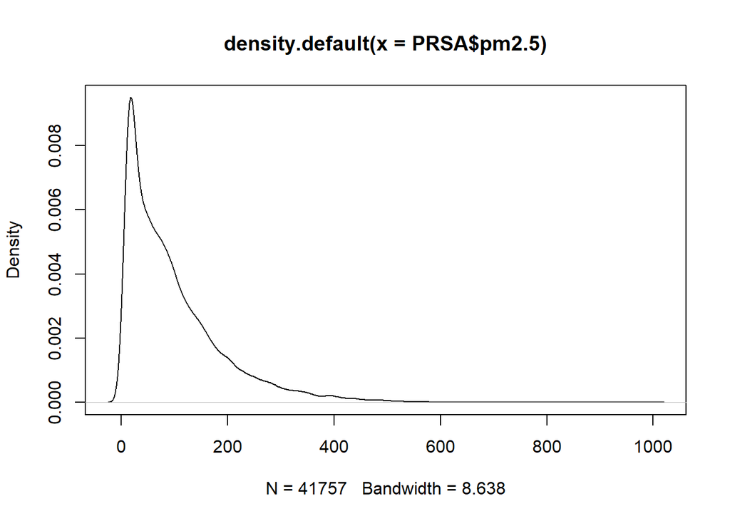

```r
plot(density(PRSA$pm2.5))
```

- pm2.5는 오른쪽으로 꼬리가 긴 비대칭의 분포를 나타내고 있음을 확인할 수 있다. 이러한 점을 감안하여 이진화를 위한 cut-off point는 중앙값인 72로 설정하도록 한다. 평균값을 고려할 수도 있겠지만 이는 이상점이나 분포에 민감한 특성이 있으므로 이러한 사항에 상대적으로 둔감한 중앙값을 설정하는 것이 좋다고 판단된다.

```r
median(PRSA$pm2.5)
```

```
## [1] 72
```

- 이를 바탕으로 반응변수 pm2.5에 대한 이진화를 실시하고 이를 통해 만들어지는 새로운 반응변수를 pm.bin이라고 하자. 이 과정은 다음의 코드를 통해 수행할 수 있다.

```r
PRSA$pm.bin <- ifelse(PRSA$pm2.5 >= 72, 1, 0)
```

- 즉, 변수 pm.bin은 pm2.5의 값이 72 이상이면 1, 그렇지 않으면 0의 값을 가진다. 이 변수를 바탕으로 로지스틱 회귀모형을 적합해보도록 한다.

`3` 로지스틱 회귀모형식은 다음과 같다. (logistic regression model)

- $\log [\frac{p_{i}}{1-p_{i}}]=\beta_{0}+\beta_{1}x_{1i}+\beta_{2}x_{2i}+\beta_{3}x_{3i}+\beta_{4}x_{4i}+\beta_{5}x_{5i}+\beta_{6}x_{6i}$
- 여기에서 확률 $p_{i}$는 pm2.5의 값이 72 이상일 확률을 나타낸다. 모형적합은 다음과 같이 할 수 있다.

```r
model1 <- glm(pm.bin ~ DEWP+TEMP+PRES+Iws+Is+Ir, family=binomial, data=PRSA)
summary(model1)
```

```
##
## Call:
## glm(formula = pm.bin ~ DEWP + TEMP + PRES + Iws + Is + Ir, family = binomial,
##     data = PRSA)
##
## Deviance Residuals:
##     Min       1Q   Median       3Q      Max
## -2.0998  -0.9209   0.5688   0.8825   3.8429
##
## Coefficients:
##               Estimate Std. Error z value Pr(>|z|)
## (Intercept) 36.0726249  2.1131721  17.070   <2e-16 ***
## DEWP         0.1229610  0.0017939  68.545   <2e-16 ***
## TEMP        -0.1433102  0.0021903 -65.430   <2e-16 ***
## PRES        -0.0337163  0.0020651 -16.327   <2e-16 ***
## Iws         -0.0121893  0.0004399 -27.712   <2e-16 ***
## Is           0.0087103  0.0142926   0.609    0.542
## Ir          -0.2449058  0.0114502 -21.389   <2e-16 ***
## ---
## Signif. codes:  0 '***' 0.001 '**' 0.01 '*' 0.05 '.' 0.1 ' ' 1
##
## (Dispersion parameter for binomial family taken to be 1)
##
##     Null deviance: 57884  on 41756  degrees of freedom
## Residual deviance: 46315  on 41750  degrees of freedom
## AIC: 46329
##
## Number of Fisher Scoring iterations: 5
```

- 적합결과, 설명변수 Is(Cumulated hours of snow)만 유의수준 $\alpha=0.05$ 기준에서 유의하지 않고 나머지 5개의 설명변수들은 모두 모형에 유의한 영향력이 있음을 알 수 있다. 이 모형에 대하여 몇가지 plot을 그리면 다음과 같다.

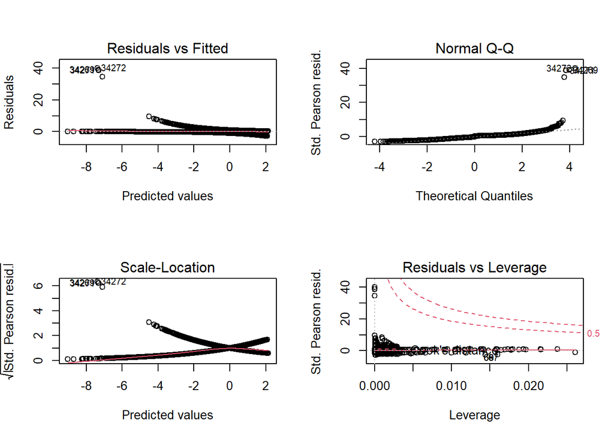

```r
par(mfrow=c(2,2))
plot(model1)
```

```r
par(mfrow=c(1,1))
```

- plot을 통해서 살펴봤을 때 약간의 이상점이 존재하기는 하지만 전체적으로 적합된 모형이 안정적이라는 생각이 든다. 추가로 probit, cloglog 링크를 사용하는 모형을 다음과 같이 적합해볼 수 있다.

`4` probit link

- 모형식 : $\Phi^{-1}(p_{i})=\beta_{0}+\beta_{1}x_{1i}+\beta_{2}x_{2i}+\beta_{3}x_{3i}+\beta_{4}x_{4i}+\beta_{5}x_{5i}+\beta_{6}x_{6i}$
- $\Phi$ : CDF of $N(0,1^2)$

```r
model2 <- glm(pm.bin ~ DEWP+TEMP+PRES+Iws+Is+Ir, family=binomial(link = probit), data=PRSA)
summary(model2)
```

```
##
## Call:
## glm(formula = pm.bin ~ DEWP + TEMP + PRES + Iws + Is + Ir, family = binomial(link = probit),
##     data = PRSA)
##
## Deviance Residuals:
##     Min       1Q   Median       3Q      Max
## -2.1209  -0.9333   0.5682   0.8903   4.7370
##
## Coefficients:
##               Estimate Std. Error z value Pr(>|z|)
## (Intercept) 21.6954489  1.2540445  17.300   <2e-16 ***
## DEWP         0.0736970  0.0010253  71.875   <2e-16 ***
## TEMP        -0.0859936  0.0012611 -68.192   <2e-16 ***
## PRES        -0.0202836  0.0012257 -16.548   <2e-16 ***
## Iws         -0.0068288  0.0002386 -28.618   <2e-16 ***
## Is           0.0032180  0.0085123   0.378    0.705
## Ir          -0.1413392  0.0064988 -21.749   <2e-16 ***
## ---
## Signif. codes:  0 '***' 0.001 '**' 0.01 '*' 0.05 '.' 0.1 ' ' 1
##
## (Dispersion parameter for binomial family taken to be 1)
##
##     Null deviance: 57884  on 41756  degrees of freedom
## Residual deviance: 46366  on 41750  degrees of freedom
## AIC: 46380
##
## Number of Fisher Scoring iterations: 5
```

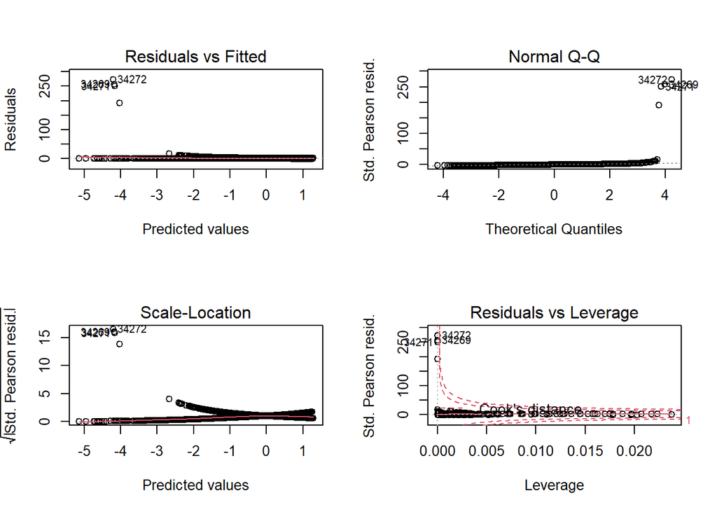

```r
par(mfrow=c(2,2))
plot(model2)
```

```r
par(mfrow=c(1,1))
```

`5` cloglog link

- 모형식 : $\log (-\log (1-p_{i}))=\beta_{0}+\beta_{1}x_{1i}+\beta_{2}x_{2i}+\beta_{3}x_{3i}+\beta_{4}x_{4i}+\beta_{5}x_{5i}+\beta_{6}x_{6i}$

```r
model3 <- glm(pm.bin ~ DEWP+TEMP+PRES+Iws+Is+Ir, family=binomial(link = cloglog), data=PRSA)
summary(model3)
```

```
##
## Call:
## glm(formula = pm.bin ~ DEWP + TEMP + PRES + Iws + Is + Ir, family = binomial(link = cloglog),
##     data = PRSA)
##
## Deviance Residuals:
##     Min       1Q   Median       3Q      Max
## -2.2404  -0.9117   0.5008   0.9058   3.4588
##
## Coefficients:
##              Estimate Std. Error z value Pr(>|z|)
## (Intercept) 18.442557   1.351411  13.647   <2e-16 ***
## DEWP         0.087299   0.001284  67.981   <2e-16 ***
## TEMP        -0.100648   0.001500 -67.099   <2e-16 ***
## PRES        -0.017320   0.001322 -13.103   <2e-16 ***
## Iws         -0.009389   0.000342 -27.456   <2e-16 ***
## Is          -0.004308   0.008469  -0.509    0.611
## Ir          -0.173754   0.008806 -19.730   <2e-16 ***
## ---
## Signif. codes:  0 '***' 0.001 '**' 0.01 '*' 0.05 '.' 0.1 ' ' 1
##
## (Dispersion parameter for binomial family taken to be 1)
##
##     Null deviance: 57884  on 41756  degrees of freedom
## Residual deviance: 46529  on 41750  degrees of freedom
## AIC: 46543
##
## Number of Fisher Scoring iterations: 6
```

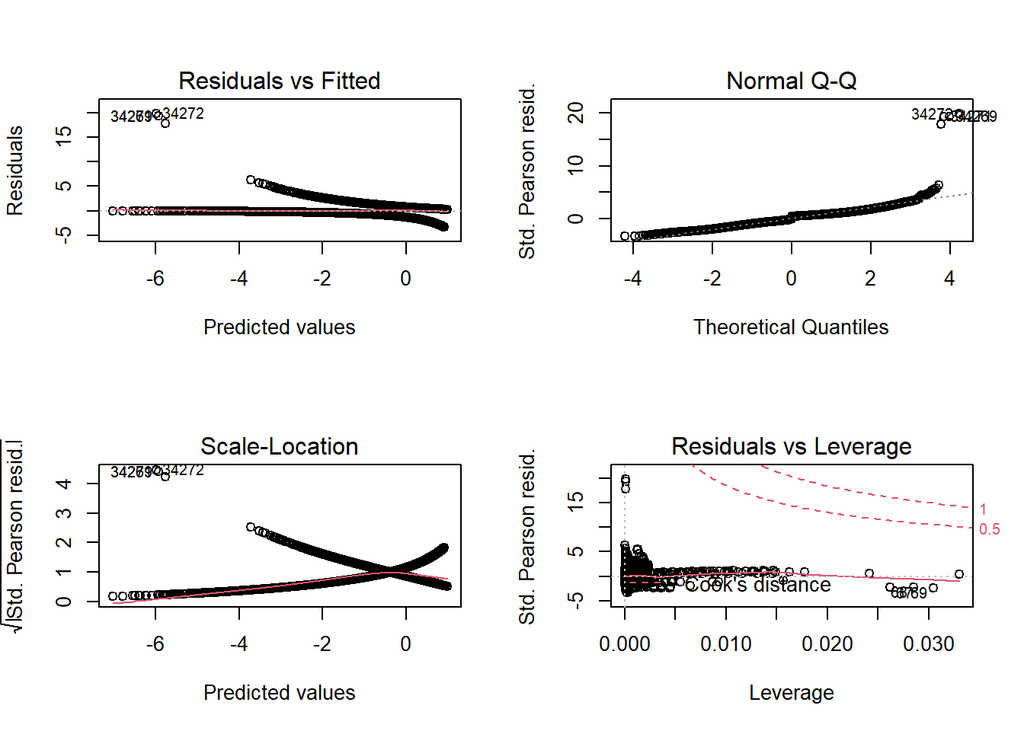

```r
par(mfrow=c(2,2))
plot(model3)
```

```r
par(mfrow=c(1,1))
```

`6` summary

- `3`~`5`를 통해서 살펴보면 link를 probit이나 cloglog로 바꿔서 모형을 적합해도 로지스틱 회귀모형을 적합했을 때의 결과와 비교했을 때 설명변수에 대한 유의성의 측면이나 이상점의 유무, 모형의 안정성 등의 측면에서 거의 동일한 해석을 이끌어낼 수 있음을 확인할 수 있다. 그리고 설명변수들 중 가장 영향력이 큰 변수는 DEWP(Dew Point)이며, 유의하지 않은 설명변수인 Is(Cumulated hours of snow)를 제거하거나 이상점이라고 판단되는 관측치를 제거하고 모형을 적합해보는 것도 괜찮은 방법이라고 생각한다.

`7` kernel smoothing regression, local linear regression

- `3`~`6`을 통해 가장 유의하다고 판단되는 설명변수인 DEWP(Dew Point)에 대해서 반응변수 pm2.5에 대한 kernel smoothing regression을 실시해보도록 한다. 여기에서 커널함수는 상대적으로 유연성이 좋다고 알려진 Gaussian kernel을 사용하여 국소상수인 Nadaraya-Watson 추정량을 사용하는 kernel smoothing regression과 각 설명변수의 값 근처에서 국소적으로 선형화하는 방법을 적용하는 local linear regression을 실시해보도록 한다. 이외에도 다양한 형태의 kernel이 존재한다.

```r
library(KernSmooth)
```

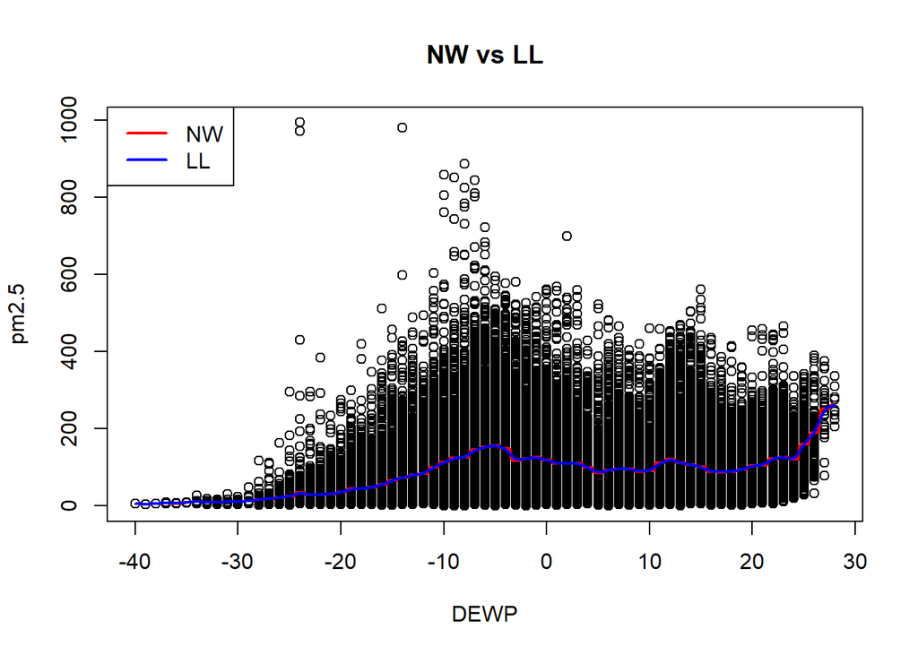

```r
with(PRSA, {
    plot(DEWP, pm2.5, main="NW vs LL")
    lines(ksmooth(DEWP, pm2.5, kernel="normal", bandwidth=0.5), col='red', lwd=2)
    lines(locpoly(DEWP, pm2.5, kernel="normal", bandwidth=0.5), col='blue', lwd=2)
    legend("topleft", legend=c("NW","LL"), col=c('red','blue'), lwd=c(2,2))
})
```

- y축의 범위를 좁혀서 좀 더 자세하게 살펴보면 다음과 같다.

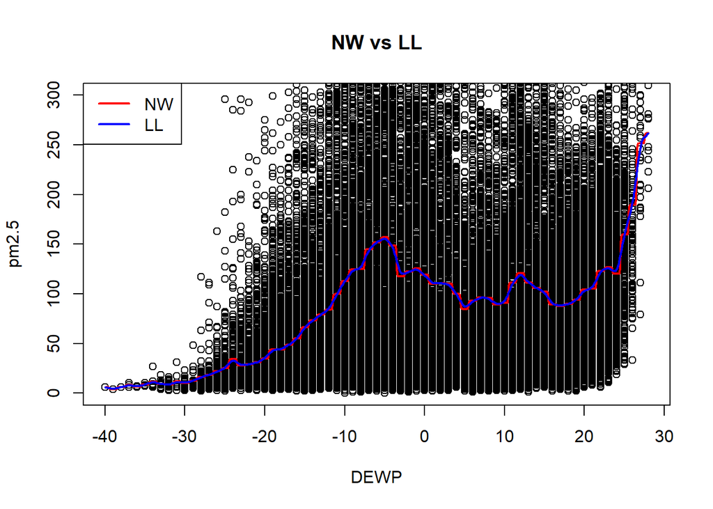

```r
with(PRSA, {
    plot(DEWP, pm2.5, ylim=c(0,300), main="NW vs LL")
    lines(ksmooth(DEWP, pm2.5, kernel="normal", bandwidth=0.5), col='red', lwd=2)
    lines(locpoly(DEWP, pm2.5, kernel="normal", bandwidth=0.5), col='blue', lwd=2)
    legend("topleft", legend=c("NW","LL"), col=c('red','blue'), lwd=c(2,2))
})
```

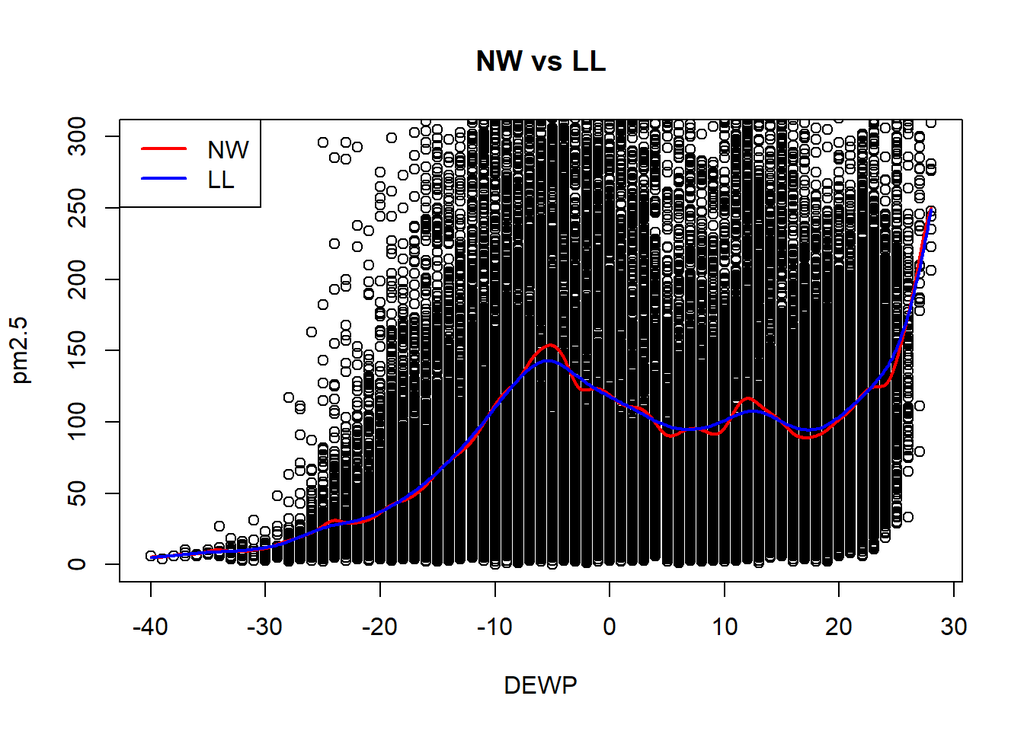

```r
with(PRSA, {
    plot(DEWP, pm2.5, ylim=c(0,300), main="NW vs LL")
    lines(ksmooth(DEWP, pm2.5, kernel="normal", bandwidth=2), col='red', lwd=2)
    lines(locpoly(DEWP, pm2.5, kernel="normal", bandwidth=2), col='blue', lwd=2)
    legend("topleft", legend=c("NW","LL"), col=c('red','blue'), lwd=c(2,2))
})
```